```python
#!/usr/bin/env python

### PRIMARY TOOLKITS ###
import numpy as np # Numpy Numerical Toolkit
import pandas as pd # Pandas Dataframes
import scipy as sp  # Scipy Scientific Toolkit

### PANDAS TOOLKITS ###
import patsy # Regression Formatting
import statsmodels.api as sm # StatsModels Statsistics Toolkit
from statsmodels.sandbox.stats.multicomp import multipletests # Statsmodels p correction

### PLOTTING ###
import matplotlib.pyplot as plt
import seaborn as sns
%matplotlib inline

### FUNCTIONALITY ###
import os # Tool for terminal and operating system type calls
import glob # Tool to Regex Search for Files
import itertools # Iterate through data
import time # Time and Date Tools
import random # Generate Random Values
import copy # Generate copy and deepcopy of objects
from decimal import Decimal
random.seed(54321)  # Set Random Seed for Reproducibility

### NOTEBOOK ###
from IPython.display import display
from IPython.core.interactiveshell import InteractiveShell # Set Notebook to Evaulate Variables on All Lines (not just last line)
InteractiveShell.ast_node_interactivity = "all"
from IPython.utils import io # Used to capture the output of cells and write to file

### BROOKS TOOLS ###
from brooks import *

### PRINT DATE AND TIME ###
print (' - Date: '+time.strftime("%d/%m/%Y")+' '+time.strftime("%H:%M:%S")+' - ')
```

```
 - Date: 09/11/2017 14:22:08 -
```

# ------------------------------------------------------------------------------

#### Vanderbilt Genetics Institute

#### andrew.w.brooks(at)vanderbilt.edu

# ------------------------------------------------------------------------------

#### Released under the MIT and Beerware Licenses

#### Copyright (c) 2017 Andrew W. Brooks

#### "MIT License" - Permission is hereby granted, free of charge, to any person obtaining a copy of this software and associated documentation files (the "Software"), to deal in the Software without restriction, including without limitation the rights to use, copy, modify, merge, publish, distribute, sublicense, and/or sell copies of the Software, and to permit persons to whom the Software is furnished to do so, subject to the following conditions: The above copyright notice and this permission notice shall be included in all copies or substantial portions of the Software. The software is provided "as is", without warranty of any kind, express or implied, including but not limited to the warranties of merchantability, fitness for a particular purpose and noninfringement. In no event shall the authors or copyright holders be liable for any claim, damages or other liability, whether in an action of contract, tort or otherwise, arising from, out of or in connection with the software or the use or other dealings in the software.

#### "Beerware License" - Andrew W. Brooks (2017) wrote this code. As long as you retain this notice and attribute my name, you can do whatever you want with this stuff. If we meet someday, and you think this stuff is worth it, you can buy me a beer in return.

# ------------------------------------------------------------------------------

# - Playplace -

#### Where all of your wildest dreams come true!

### - DF - Pandas Class -

#### Class to store Pandas Dataframe object and perform analyses.

```python
##################################################################################
##################################################################################
##################################################################################
##################################################################################
##################################################################################
####### PANDAS & STATISTICAL TOOLS (DataFrame - pandas ) #########################
# Class to contain a pandas dataframe and additional info
# Tools include: Statistics, Plotting
class DF:

    ### CLASS INITIALIZATION ##################################################
    def __init__(self, source, sepIn='\t', verboseIn=True, columnsIn=None, indexIn=None):
        ##### DATA STRUCTURES #####
        ### VERBOSE BOOL .verbose ###
        self.verbose = verboseIn
        ### SEPARATOR BOOL .sep ### Default '\t'
        self.sep=sepIn
        ##### INPUT PATH .path ###
        self.source=source
        ### SET PALETTE ###
        self.palette = None
        ### SET COLUMNS AND INDEX IF PROVIDED ###
        if columnsIn != None: self.columns = columnsIn
        if indexIn   != None: self.index = indexIn
        ##### LOAD FROM PROVIDED SOURCE #####
        self = self.load()
        ### UPDATE COLUMNS ###
        self.columns = list(self.df.columns)
        ### UPDATE INDEX ###
        self.index = list(self.df.index)

    ### SET ACTION IF CALLED BY PRINT() ######################################
    def __str__(self):
        self.display()
        return ""

    ### SET ACTION IF CALLED WITH NO COMMAND #################################
    def __repr__(self):
        self.display()
        return ""

    ##########################################################################
    ########################## COPY ##########################################

    ### COPY .copy() Return unconnected copy of class object.
    def copy(self): return copy.deepcopy(self)

    ##########################################################################
    ########################## DISPLAY #######################################

    ### DISPLAY IN NOTEBOOK ###
    def display(self):
        display(self.df)

    ### DISPLAY PANDAS - SCIENTIFIC NOTATION ###
    def display_scientific(self, dispPos=3):
        pd.set_option('display.float_format', '{:.'+str(dispPos)+'g}'.format)

    ### DISPLAY PANDAS - FLOAT NOTATION ###
    def display_float(self, dispPos=3):
        pd.set_option('display.float_format', '{:.5f}'.format)

    ### DISPLAY PANDAS - MAX COLUMN WIDTH (-1 = No Wrap) ###
    def display_colwidth(self, widthIn=-1):
        pd.set_option('display.max_colwidth', widthIn)

    ##########################################################################
    ########################### I/O ##########################################

    ### MAIN LOAD FUNCTION ###
    def load(self):
        ##### DATAFRAME .df #########
        iB=False # BOOL INPUT SUCCESS #
        ### IF DF() CLASS THEN SET AS SELF ###
        if isinstance(self.source, DF): self = copy.deepcopy(self.source); iB=True
        ### IF STRING IMPORT AS TSV PATH ###
        elif isinstance(self.source, str): self.load_tsv(); iB=True
        ### IF NONE THEN MAKE EMPTY DATAFRAME
        elif self.source is None:
            self.df = pd.DataFrame(index=self.index, columns=self.columns, dtype=None, copy=False)
            self.df.fillna(0); iB = True
        ### IF INT OR FLOAT THEN FILL DATARAME WITH VALUE ###
        elif (isinstance(self.source, int)) or (isinstance(self.source,float)):
            self.df = pd.DataFrame(index=self.index, columns=self.columns, dtype=None, copy=False)
            self.df.fillna(self.source); iB = True
        ### IF PANDAS DF THEN COPY ###
        elif isinstance(self.source, pd.DataFrame): self.df = self.source.deepcopy(); iB=True
        ### IF DICT THEN FORMAT AS DF ###
        elif isinstance(self.source, dict): self.load_dict(self.source); iB=True
        ### ELSE TRY IMPORTING AS OBJECT ###
        else:  self.load_obj(self.source);iB=True
        ### ELSE ISSUE ERROR AND INITIALIZE AS EMPTY
        if not iB:
            print("  WARNING: Could not import DF from provided source. Initialized empty.")
            self.df = pd.DataFrame(index=indexIn, columns=columnsIn, dtype=None, copy=False);self.df.fillna(0)
        return self

    ### DF FROM TSV ### -> self
    def load_tsv(self):
        if self.verbose is True: print("  LOADING: File " + self.source);
        self.df = pd.read_csv(self.source, sep=self.sep, index_col=None, skiprows=0, verbose=False, low_memory=False)
        if self.verbose is True: print("  SUCCESS: Loaded DF.")
        return self

    ### DF FROM DICTIONARY ### -> self
    def load_dict(self, dictIn):
        if self.verbose is True: print("  CREATING: DF from Dictionary.")
        self.df = pd.DataFrame.from_dict(dictIn, orient='columns', dtype=None)
        if self.verbose is True: print("  SUCCESS: Created DF from Dictionary.")
        return self

    ### DF FROM RECORD ###  -> self (objIn i.e. ndarray(i.e.structured dtype), list of tuples, dict, or DataFrame
    def load_obj(self, objIn):
        if self.verbose is True: print("  CREATING: DF from Object.")
        self.df = pd.DataFrame.from_records(data=objIn, columns=self.columns, index=self.index, coerce_float=True)
        if self.verbose is True: print("  SUCCESS: Created DF from Object.")
        return self

    ### DF TO TSV FILE ### -> self
    def write(self, outPath):
        if self.verbose is True: print("  WRITING: DF to File "+outPath)
        self.df.to_csv(outPath, sep=self.sep)
        if self.verbose is True: print("  SUCCESS: DF Written to File "+outPath)
        return self

    ##########################################################################
    ####################### TABLE MANIPULATION ###############################

    ##### COLUMNS ######################

    ### ADD COLUMNS (cols) ###
    def columns_add(self, name, data):
        kwargs = {name:data}
        self.df = self.df.assign(**kwargs)
        self.update()
```

```python
    ### DROP COLUMNS FROM DATAFRAME ###
    def columns_drop(self, columns):
        self.df.drop(labels=columns, axis='columns', inplace=True, errors='raise')
        self.update()

    ### CONVERT COLUMN TO NUMERIC ###
    def columns_numeric(self, name, strnan=True):
        if strnan == True: errors = 'coerce'#Errors can be 'coerce' (strings to NaN)
        else: errors = 'raise' #Errors can be 'raise' (raises error)
        self.df[name] = pd.to_numeric(self.df[name], errors=errors)
        self.update()

    ### CONVERT COLUMN TO STRING ###
    def columns_str(self, name):
        self.df[name] = [str(y) for y in self.df[name]] # Cast Column to Str #
        self.update()

    ### YIELD BY COLUMNS (cols) ###
    def columns_yield(self):
        for cCur in self.columns:
            yield self.df[[cCur]]

    ##### INDEX ########################

    ### ADD INDEX (row) ###
    def index_add(self, name, data):
        self.df.loc[name] = data
        self.update()

    ### DROP INDICES FROM DATAFRAME ###
    def index_drop(self, indices):
        self.df.drop(labels=columns, axis='index', inplace=True, errors='raise')
        self.update()

    ### CONVERT INDEX TO NUMERIC ###
    def index_numeric(self, strnan=True):
        if strnan == True: errors = 'coerce'#Errors can be 'coerce' (strings to NaN)
        else: errors = 'raise' #Errors can be 'raise' (raises error)
        self.df.index = pd.to_numeric(self.df.index, errors=errors)
        self.update()

    ### SET INDEX COLUMN OR COLUMNS ###
    def index_set(self, colNameOrList, drop=True, append=False):
        self.df.set_index(colNameOrList, drop=drop, append=append, inplace=True, verify_integrity=False)
        self.update()

    ### CONVERT INDEX TO STRING ###
    def index_str(self):
        self.df.index = [str(y) for y in self.index]
        self.update()

    ### YIELD BY INDICES (rows) ###
    def index_yield(self):
        for iCur in self.index:
            yield self.df.loc[[iCur]]

    ##### ADDITIONAL ###################

    ### REPLACE IN DATAFRAME ###
    def replace(self, toReplace, replaceWith): self.df.replace(to_replace=toReplace, value=replaceWith, inplace=True, limit=None, regex=False, method='pad')

    ### RESET .reset() ###
    def reset(self): return self.__init__(self.source)

    ### UPDATE SELF VALUES BASED ON TABLE ###
    def update(self):
        ### UPDATE COLUMNS ###
        self.columns = list(self.df.columns)
        ### UPDATE INDEX ###
        self.index = list(self.df.index)


    ##########################################################################
    ############################ PALETTE #####################################

    ### DISPLAY A PREVIEW OF THE PALETTE ...ooooh pretty ###
    def palette_preview(self):
        sns.palplot(self.palette)

    ### SET .palette FOR A RAINBOW OF COLORS ###
    def palette_heatmap(self, numColors):
        self.palette = sns.palplot(sns.color_palette("coolwarm", numColors))

    ### SET .palette FOR A HEATMAP OF COLORS ###
    def palette_rainbow(self, numColors, lightIn=0.5, saturationIn=0.8, previewIn=False):
        self.palette = sns.hls_palette(numColors, l=lightIn, s=saturationIn)

    ##########################################################################
    ########################## USER INTERFACE ################################
    """
    ### USER INTERFACE - SELECT FILE ###
    def ui_selectfile(initialdir='/Users/brooks/Dropbox/'):
        root = tk.Tk()
        root.withdraw()
        filename = filedialog.askopenfilename(initialdir=initialdir)
        root.update()
        return filename

    ### USER INTERFACE - SELECT DIRECTORY ###
    def ui_selectdir(initialdir='/Users/brooks/Dropbox/'):
        root = tk.Tk()
        root.withdraw()
        dirname = filedialog.askdirectory(initialdir=initialdir)
        root.update()
        return dirname
    """
    ##########################################################################
    ########################### PLOTTING #####################################

    # fig, ((ax1, ax2), (ax3, ax4)) = plt.subplots(2, 2, sharex=True, sharey=True)

    ### LINEAR MODEL PLOT ### continuousXcontinuous, 95%CI, can color and split plots by categories.
    def plot_lm(self, continuousColX, continuousColY, categoricalColor=None, categoricalRow=None, categoricalColumn=None):
        plt.clf(); f = plt.figure(figsize=(5,5))
        ### SET STYLE ###
        sns.set(style="ticks", context="talk"); pal=None
        ### GET COLOR PALETTE ###
        if categoricalColor != None: self.palette_rainbow(len(self.df[categoricalColor].unique()), lightIn=0.7, saturationIn=1.0 )
        ### MAKE LINEAR MODEL PLOT ###
        sns.lmplot(x=continuousColX,y=continuousColY,row=categoricalRow,col=categoricalColumn,hue=categoricalColor,data=self.df, size=7, palette=self.palette, ci=95)
        plt.show(); plt.clf()

    ### VIOLIN PLOT ### categoricalXcontinuous, color ideal with two groups.
    def plot_violin(self, xcat, ycon, hue=None, saveloc=None):
        f = plt.figure(figsize=(16,10))
        sns.set(font_scale=2)
        ### IF CATEGORICAL COLOR ON EACH HALF OF VIOLIN ###
        splitIn = False;
        if hue != None:
            if len(self.df[hue].unique()) == 2: splitIn = True
            ### GET COLOR PALETTE ###
            self.palette_rainbow(len(self.df[hue].unique()), lightIn=0.7, saturationIn=1.0 )
        ### MAKE VIOLIN AND POINT PLOT ###
        sns.violinplot(x=xcat, y=ycon, hue=hue, data=self.df, split=splitIn, palette=self.palette)
        sns.boxplot(x=xcat, y=ycon, hue=hue, data=self.df, linewidth=10, showmeans=True)
        sns.stripplot(x=xcat, y=ycon, hue=hue, data=self.df, alpha=0.8, linewidth=2, jitter=True, orient='v', edgecolor='b')
        ### SAVE OR SHOW RESULTS ###
        if saveloc != None: plt.savefig(saveloc)
        else: plt.show(); plt.clf(); plt.close()
        return

    ##########################################################################
    ########################## STATS ####################################
    ##### .stats_X STATISTICS FUNCTIONS #####################
```

```python
    ### LINEAR REGRESSION - ORDINARY LEAST SQUARES
    # regResults, regDependent, regPredictors = stats_regression(mapDF, regEquation=" age_years ~ bmi + race + race:sex ")
    def stats_regression(self, regEquation=" age_years ~ bmi + sex:race ", printOut=True):
        ### GET VARIABLES INTO X[n,p] predictors and y[n,1] outcome
        y, X = patsy.dmatrices(regEquation, self.df, return_type='dataframe')
        ### GENERATE OLS REGRESSION MODEL ###
        statsModel = sm.OLS(y, X, disp=0)
        ### FIT DATA TO A LINE USING OLS MINIMIZATION ###
        statsModelFit = statsModel.fit(disp=0)
        ### PRINT RESULTS ###
        if printOut == True: print(statsModelFit.summary())
        ### RETURN: resultsObject, y, X
        return statsModelFit, y, X

    """
    ### LOGISTIC REGRESSION
    # regResults, regDependent, regPredictors = stats_regression(mapDF, regEquation=" age_years ~ bmi + race + race:sex ")
    def stats_logistic(self, regEquation=" age_years ~ bmi + sex:race ", printOut=True):
        ### GET VARIABLES INTO X[n,p] predictors and y[n,1] outcome
        y, X = patsy.dmatrices(regEquation, self.df, return_type='matrix')
        ### GENERATE OLS REGRESSION MODEL ###
        statsModel = sm.Logit(y[:, 0], X, disp=0)
        ### FIT DATA TO A LINE USING OLS MINIMIZATION ###
        statsModelFit = statsModel.fit(method='bfgs', disp=0)
        ### PRINT RESULTS ###
        if printOut == True: print(statsModelFit.summary())
        ### RETURN: resultsObject, y, X
        return statsModelFit, y, X
    """

    ### MANN-WHITNEY-U PAIRWISE CONTINUOUS VARIABLE BY CATEGORICAL COLUMN ###
    def stats_mwu_pairwise(self, con, cat, split=None):
        if self.verbose is True: print(" - Comparing "+con+" by "+cat+" - ")
        ### SETUP DATAFRAME ###
        resDF = DF(None, columnsIn=['g1','g2','g1n','g2n','p','t'], indexIn=[])
        ### GET ALL PAIRWISE COMBINATIONS OF DISTANCE MATRICES ###
        for catIDX, (cat1,cat2) in enumerate(itertools.combinations(self.df[cat].unique(),2)):
            ### CALCULATE MANN-WHITNEY-U ###
            testStat, pValue = sp.stats.mannwhitneyu(self.df[self.df[cat]==cat1][con],
                                                     self.df[self.df[cat]==cat2][con],
                                                     use_continuity=True, alternative='two-sided')
            ### STORE RESULTS ###
            resDF.df.loc[catIDX] = [cat1,cat2,
                                    len(self.df[self.df[cat]==cat1][con]),len(self.df[self.df[cat]==cat2][con]),
                                    pValue,testStat]
        return resDF
```

```python
df = DF('/Users/brooks/Dropbox/Vanderbilt/American_Gut/Data_Pipeline/1_3_alpha_map_1000.txt')
```

```
  LOADING: File /Users/brooks/Dropbox/Vanderbilt/American_Gut/Data_Pipeline/1_3_alpha_map_1000.txt
  SUCCESS: Loaded DF.
```

```
 - Comparing shannon by race -
```

|  | g1 | g2 | g1n | g2n | p | t |
| --- | --- | --- | --- | --- | --- | --- |
| 0 | Caucasian | Hispanic | 1237.0 | 37.0 | 2.389952e-02 | 17903.0 |
| 1 | Caucasian | Asian or Pacific Islander | 1237.0 | 88.0 | 9.839096e-08 | 72913.0 |
| 2 | Caucasian | African American | 1237.0 | 13.0 | 3.839350e-02 | 10722.0 |
| 3 | Hispanic | Asian or Pacific Islander | 37.0 | 88.0 | 2.638370e-06 | 2497.0 |
| 4 | Hispanic | African American | 37.0 | 13.0 | 6.969123e-03 | 363.0 |
| 5 | Asian or Pacific Islander | African American | 88.0 | 13.0 | 9.232515e-01 | 582.0 |

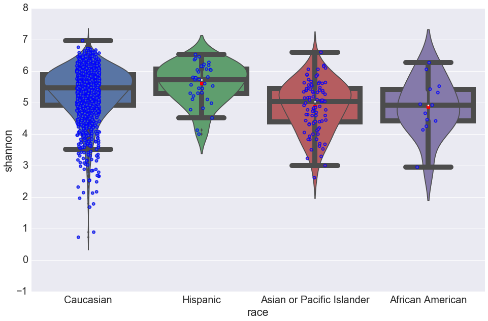

```python
df.plot_violin(xcat='race', ycon='shannon', saveloc='/Users/brooks/Dropbox/Vanderbilt/American_Gut/Figure/Fig_2/Fig_2_Alpha/Shannon_Distribution_AGP.pdf')
df.stats_mwu_pairwise(cat='race',con='shannon')
```